# Matrices

In machine learning applications situations in which all predictors are numeric, or can be converted to numerics in a meaningful way, are common. The digits data set is an example since every pixel records a number between 0 and 255.

```r
if(!exists("digits")){
  url <- "https://raw.githubusercontent.com/datasciencelabs/data/master/hand-written-digits-train.csv"
digits <- read_csv(url)
}
```

In these cases it is often convenient to save the predictors in a matrix and the outcome in a vector rather than using a data frame. The main reason is that certain mathematical operations needed to develop efficient code can be performed using techniques from a branch of mathematics called *linear algebra*. In fact, linear algebra and matrix notation are key elements of the languange used in academic papers describing machine learning techniques. We will not cover linear algebra in detail here, but will demonstrate how to use matrices in R so that you can apply the linear algebra techniques already implemented in R base or other packages.

To motivate the use of matrices we will pose several challenges.

1. Study the distribution of the total pixel darkness and how it varies by digits. Maybe this can help with classification.
2. Study the variation of each pixel and remove columns associated with pixels that don’t change much, thus not informing the classification.
3. Zero out low values. First, look at the distribution of all pixel values, use this to pick a cutoff to define unwritten space. Then set anything below that cutoff to 0.
4. Dichotomize the data. First, look at the distribution of all pixel values, use this to pick a cutoff to distinguish between writing and no writing. Then convert all entries into either 1 or 0 respectively.
5. Scale each of the predictors in each entry to have the same average and standard deviation.

To complete these we will have to perform mathematical operations involving several variables. The tidyverse is not developed to perform these types of mathematical operations. For this task it is convenient to use matrices.

Before we do this, we will introduce matrix notation and basic R code to define and operate on matrices.

## Notation

In matrix algebra we have three main types of objects: scalars, vectors and matrices.

A scalar is just one number. For example $a = 1$. To denote scalars in matrix notation we usually use a lower case letter and do not bold.

Vectors are like the numeric vectors we define in R: they include several scalar entries. For example, the column containing the first pixel:

```r
X <- digits$pixel0
length(X)
```

```
## [1] 42000
```

In matrix algebra we use the following notation:

$$\mathbf{X} = \begin{pmatrix}
x_1\\\
x_2\\\
\vdots\\\
x_N
\end{pmatrix}$$

Similarly, we can use math notation to represent different features

```r
X_1 <- digits$pixel400
X_2 <- digits$pixel600
```

mathematically, by adding an index:

$$\mathbf{X}_1 = \begin{pmatrix}
x_{1,1}\\
\vdots\\
x_{N,1}
\end{pmatrix} \mbox{ and }
\mathbf{X}_2 = \begin{pmatrix}
x_{1,2}\\
\vdots\\
x_{N,2}
\end{pmatrix}$$

A matrix can be defined as a series of vectors of the same size joined together each forming a column:

```r
X <- cbind(X_1, X_2)
X[1:5,]
```

```
##      X_1 X_2
## [1,]   0   0
## [2,] 254 254
## [3,]   0 185
## [4,]  67   0
## [5,] 253 253
```

Mathematically we represnt them with bold upper case letters:

$$\mathbf{X} = [ \mathbf{X}_1 \mathbf{X}_2 ] = \begin{pmatrix}
x_{1,1} & x_{1,2}\\
\vdots & \vdots\\
x_{N,1} & x_{N,2}\\
\end{pmatrix}$$

The *dimenstion* of a matrix is often an important characteristic needed to assure certain operations can be performed. The *dimension* is a two number summary defined as the number of rows $\times$ the number of columns. In R we can extract the dimenstion of a matrix with the function `dim`:

```r
dim(X)
```

```
## [1] 42000     2
```

Note that vectors can be thought of as $N\times 1$ matrices. However, in R a vector does not have dimensions:

```r
dim(X_1)
```

However, we can explcitly convert a vector into a matrix using the function `as.matrix`:

```r
dim(as.matrix(X_1))
```

```
## [1] 42000     1
```

We can use this notation to denote an arbitrary number of covariates with the following $N\times p$ matrix, with $p=784$:

$$\mathbf{X} = \begin{pmatrix}
x_{1,1}&\dots & x_{1,p} \\
x_{2,1}&\dots & x_{2,p} \\
& \vdots & \\
x_{N,1}&\dots & x_{N,p}
\end{pmatrix}$$

We can extract this matrix from our data frame using the `as.matrix` function:

```r
X <- digits %>%
  select(-label) %>%
  as.matrix()
dim(X)
```

```
## [1] 42000   784
```

## Matrix operations

We will learn several useful operations related to matrix algebra. We use a few of the motivating examples listed above.

### Converting a vector to a matrix

It is often useful to convert a vector to a matrix. For example, because the variables are pixels on a grid, we can convert the rows of pixel intensities into a matrix representing this grid.

We can convert a vector into a matrix with the `matrix` function and by specifying the number of rows and columns the resulting matrix should have. The matrix is filled in by column: the first column is filled first, the second is filled second and so on. This example helps illustrate:

```r
my_vector <- 1:15
mat <- matrix(my_vector, 5, 3)
mat
```

```
##      [,1] [,2] [,3]
## [1,]    1    6   11
## [2,]    2    7   12
## [3,]    3    8   13
## [4,]    4    9   14
## [5,]    5   10   15
```

We can fill by row by using the `byrow` argument.

```r
mat_t <- matrix(my_vector, 3, 5, byrow = TRUE)
mat_t
```

```
##      [,1] [,2] [,3] [,4] [,5]
## [1,]    1    2    3    4    5
## [2,]    6    7    8    9   10
## [3,]   11   12   13   14   15
```

When we turn the columns into rows we refer to these operations as *transposing* the matrix. The function `t` can be used to directly transpose a matrix:

```r
identical(t(mat), mat_t)
```

```
## [1] TRUE
```

Note that the `matrix` function recycles values in the vector **without warning** if the product of columns and rows does not match the length of the vector:

```r
matrix(my_vector, 5, 5)
```

```
##      [,1] [,2] [,3] [,4] [,5]
## [1,]    1    6   11    1    6
## [2,]    2    7   12    2    7
## [3,]    3    8   13    3    8
## [4,]    4    9   14    4    9
## [5,]    5   10   15    5   10
```

To put the pixel intensities of our eighth entry, which is a 3, into a grid we can use:

```r
grid <- matrix(X[8,], 28, 28)
```

To confirm that in fact we have done this correctly, we can use the function `image` which shows an image of its third argument (in this case grid):

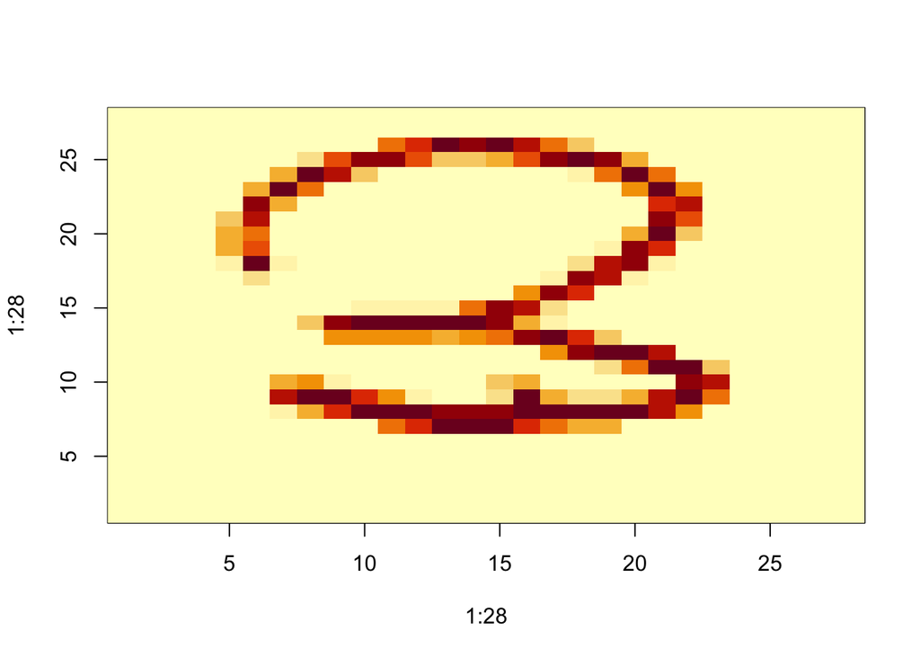

```r
image(1:28, 1:28, grid)
```

Note that the top of the image is pixel 1, but pixel 1 is shown at the bottom of the plot, so the image is flipped. To see it correctly we can use:

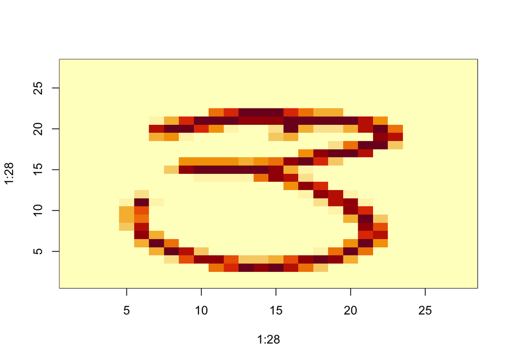

```r
image(1:28, 1:28, grid[,28:1])
```

### Row and column summaries

For the first task, related to total pixel darkness, we want to sum the values of each row and then visualize how these values vary by digit.

The function `rowSums` takes a matrix as input and computes the desired values:

```r
sums <- rowSums(X)
```

We can also compute the averages with `rowMeans` if we want the values to remain between 0 and 255:

```r
avg <- rowMeans(X)
```

Once we have this we can simply generate a boxplot:

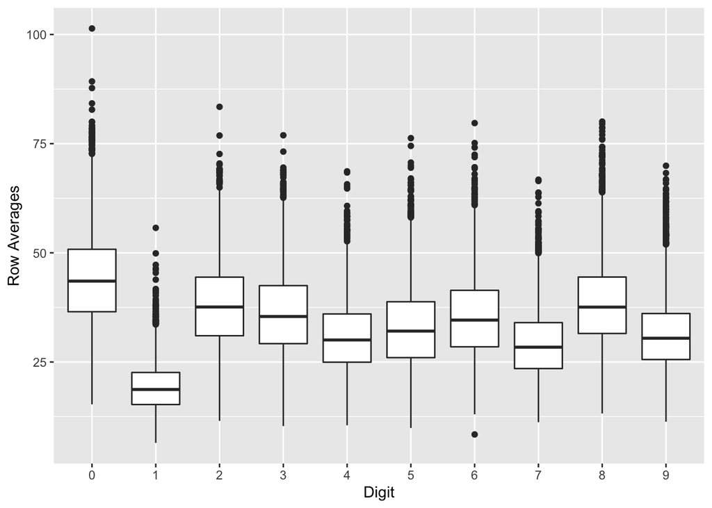

```r
digits %>% mutate(row_averages = avg) %>%
  ggplot(aes(as.factor(label), row_averages)) +
  xlab("Digit") +
  ylab("Row Averages") +
  geom_boxplot()
```

We can also compute the column sums and averages using the function `colSums` and `colMeans` respectively.

The package `matrixStats` adds functions that perform operations on each row or column very efficiently including the functions `rowSds` and `colSds`.

### `apply`

The functions just described are performing an operation similar to what `sapply` and the purrr function `map` do: apply the same function to a part of your object. In this case either each row or each column. The apply function let’s you apply any function, not just `sum` or `mean` to a matrix. The first argument is the matrix, the second is the dimension, 1 for rows, 2 for columns, and the third is the function. So, for example, `rowMeans` can be written as

```r
avgs <- apply(X, 1, mean)
```

But note that, just like with `sapply` and `map`, `apply` can perform any function. So if we wanted the population standard deviation for each column we could write

```r
popsd <- apply(X, 2, function(x){
  sqrt(mean((x-mean(x))^2))
})
```

What you pay for this flexiblity is that these are not as fast as dedicated functions such as `rowMeans`.

### Filtering columns based on summaries

We now turn to task 2: study the variation of each pixel and remove columns associated with pixels that don’t change much, thus not informing the classification. Although a simplistic approach, we will quantify the variation of each pixel with its standard deviation across all entries. Since each column represents a pixel, we use the `colSds` function from the `matrixStats` package:

```r
library(matrixStats)
sds <- colSds(X)
```

A quick look at the distribution of these values shows that some pixles have very low entry to entry variability:

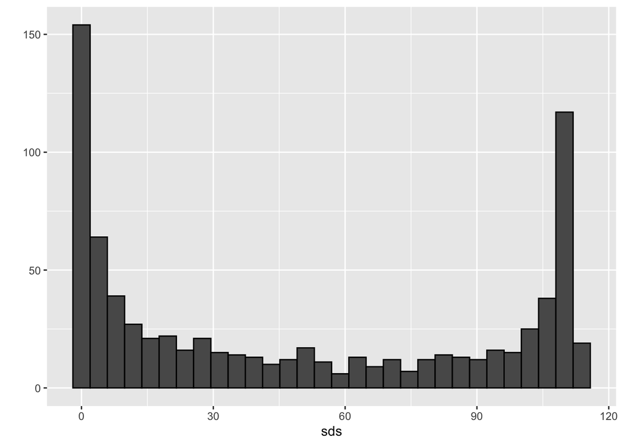

```r
qplot(sds, bins = "30", color = I("black"))
```

This makes sense since some parts of the box we don’t write in. Here is the variance plotted by location:

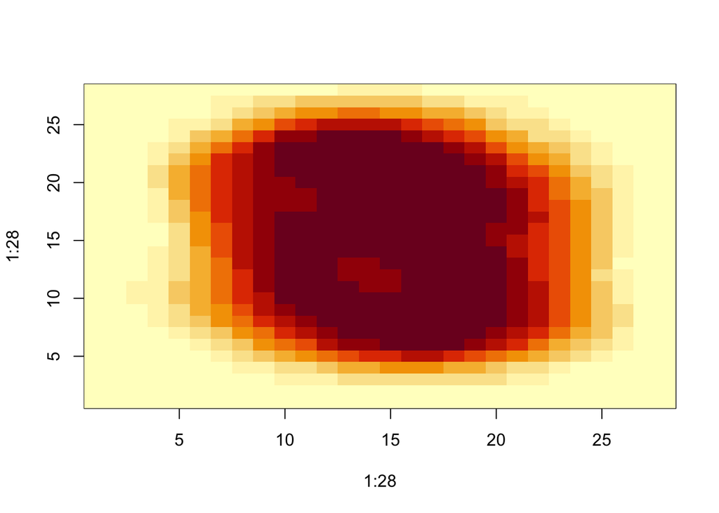

```r
image(1:28, 1:28, matrix(sds, 28, 28))
```

So we could remove features that have no variation since these can’t help us predict.

In the R section we described the operations used to extract columns

```r
X[ ,c(1,2)]
```

and rows:

```r
X[c(2,3),]
```

We can also use logical indexes to determine which columns or rows to keep. So, if we wanted to remove uniformative predictors from our matrix we could write this one line of code:

```r
X_new <- X[ , colSds(X) > 60]
dim(X_new)
```

```
## [1] 42000   323
```

Only columns for which the standard deviation is above 60 are kept, which removes over half of the predictors.

Here we add an important warning related to subsetting matrices: if you select one column or one row, the result is no longer a matrix but a vector:

```r
class(X[,1])
```

```
## [1] "numeric"
```

```r
class(X[1,])
```

```
## [1] "numeric"
```

However, we can preserve the matrix class by using the argument `drop`:

```r
class(X[, 1, drop=FALSE])
```

```
## [1] "matrix"
```

```r
dim(X[, 1, drop=FALSE])
```

```
## [1] 42000     1
```

### Indexing with matrices

```r
mat <- matrix(1:15, 5, 3)
mat
```

```
##      [,1] [,2] [,3]
## [1,]    1    6   11
## [2,]    2    7   12
## [3,]    3    8   13
## [4,]    4    9   14
## [5,]    5   10   15
```

```r
as.vector(mat)
```

```
##  [1]  1  2  3  4  5  6  7  8  9 10 11 12 13 14 15
```

So to see a histogram of all our predictor data we can use

```r
qplot(as.vector(X), bins = 30, color = I("black"))
```

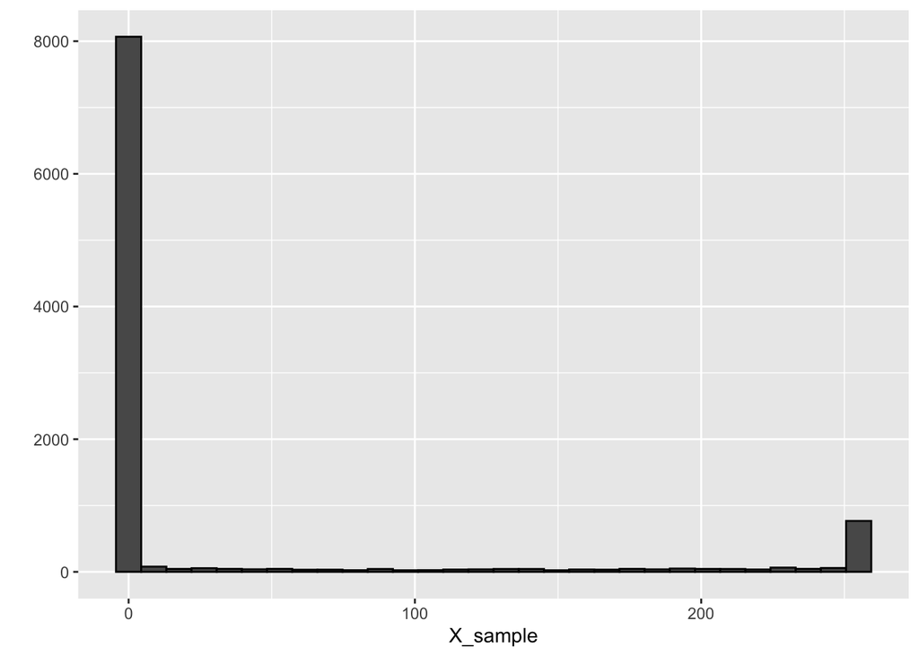

```r
X_sample <- sample(as.vector(X), 10000)
qplot(X_sample, bins = 30, color = I("black"))
```

We notice a clear dichotomy which is explained as parts with ink and parts without. If we think that values below, say, 25 are smudges we can quickly make them zero using:

```r
X[X < 25] <- 0
```

To see what this does we look at a smaller matrix:

```r
mat[mat < 3] <- 0
mat
```

```
##      [,1] [,2] [,3]
## [1,]    0    6   11
## [2,]    0    7   12
## [3,]    3    8   13
## [4,]    4    9   14
## [5,]    5   10   15
```

We can also use logical operations with matrix logicals

```r
mat[mat > 6 & mat <12] <- 0
mat
```

```
##      [,1] [,2] [,3]
## [1,]    0    6    0
## [2,]    0    0   12
## [3,]    3    0   13
## [4,]    4    0   14
## [5,]    5    0   15
```

### Dichotomizing the data

The histogram above seems to suggest that this data is mostly binary. A pixel either has ink or does not. Using what we have learned we can dichotomize the data using just matrix operations:

```r
bin_X <- X
bin_X[bin_X < 255/2] <- 0
bin_X[bin_X > 255/2] <- 1
```

We can also convert to a matrix of logicals and then coerce to numbers like this:

```r
bin_X <- (X > 255/2)*1
```

We can see that the entry we looked at before does not change much:

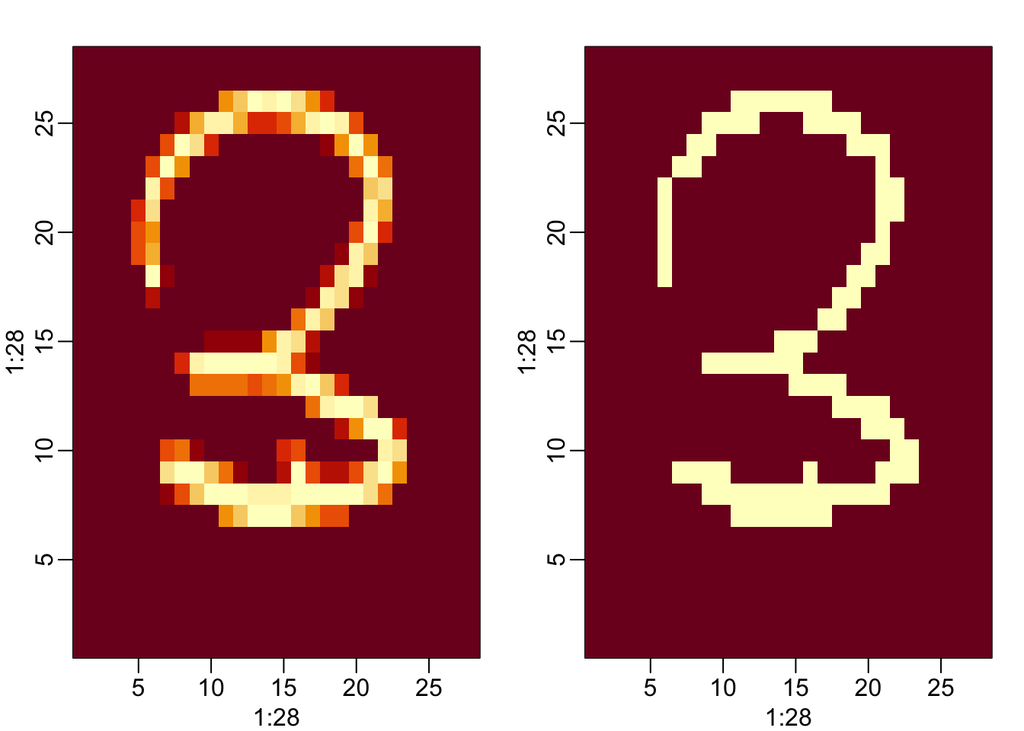

### Vectorization for matrices

In R, if we subtract a vector from a matrix, the first element of the vector is subtracted from the first row, the second element from the second row and so on. So using mathematical notation we would write it like this:

$$\begin{pmatrix}
X_{1,1}&\dots & X_{1,p} \\
X_{2,1}&\dots & X_{2,p} \\
& \vdots & \\
X_{N,1}&\dots & X_{N,p}
\end{pmatrix}
-
\begin{pmatrix}
a_1\\\
a_2\\\
\vdots\\\
a_N
\end{pmatrix}
=
\begin{pmatrix}
X_{1,1}-a_1&\dots & X_{1,p} -a_1\\
X_{2,1}-a_2&\dots & X_{2,p} -a_2\\
& \vdots & \\
X_{N,1}-a_n&\dots & X_{N,p} -a_n
\end{pmatrix}$$

The same holds true for other arithmethic operations. This implies that we can scale each row of a matrix like this:

```r
(X - rowMeans(X)) / rowSds(X)
```

If you want to scale each column, be careful, it does not work for columns. For columns you can do this using the transpose of the matrix:

```r
t( t(X) - colMeans(X) )
```

We can also use a function called `sweep` the works similarly to `apply`. It takes each entry of a vector and subtracts it from the corresponding row or column.

```r
X_mean_0 <- sweep(X, 2, colMeans(X))
```

The function `sweep` actually has another argument that lets you define the arithmetic operation. So to divide by the standard deviation we do the following:

```r
X_mean_0 <- sweep(X, 2, colMeans(X))
X_standardized <- sweep(X_mean_0, 2, colSds(X), FUN = "/")
```

## Matrix Algebra operations

Finally, although we do not cover matrix algebra operations such as matrix multiplication, we share here the relevant commands for those who know the mathematics and want to learn the code:

1. Matrix multiplication is done with `%*%` so the cross product, for example, is

   ```r
   t(X) %*% X
   ```

2. We can compute the cross product directly with the function with that name:

   ```r
   crossprod(X)
   ```

3. To compute the inverse of a function we use `solve`. Here it is applied to the crossproduct:

   ```r
   solve(crossprod(X))
   ```

4. The QR decomposition is readily available by using the `qr` function:

   ```r
   qr(X)
   ```